# 探究的データ分析：軍事費

鈴木寛

2024年2月20日

# 軍事費・教育費

> G7 (Group of Seven)、フランス（France）, アメリカ（United States）, 英国（United Kingdom）, ドイツ（Germany）, 日本（Japan）, イタリア（Italy）, カナダ（Canada）, と ヨーロッパ連合（EU, non-enumerated member) の軍事費と、教育費について、基本的なデータの分析を行う。

```r
G7 <- c("FR", "US", "GB", "DE", "JP", "IT", "CA", "EU")
```

## データ

### データ情報

- 軍事費（USD）Military expenditure (current USD)：MS.MIL.XPND.CD [[Link](https://data.worldbank.org/indicator/MS.MIL.XPND.CD)]
- 軍事費（政府の総支出に対する率（%））Military expenditure (% of general government expenditure)：MS.MIL.XPND.ZS [[Link](https://data.worldbank.org/indicator/MS.MIL.XPND.ZS)]
- 教育費（政府の総支出に対する率（%））Government expenditure on education, total (% of government expenditure)：SE.XPD.TOTL.GB.ZS [Link](https://data.worldbank.org/indicator/SE.XPD.TOTL.GB.ZS)]

### データの取得

#### 準備

*これまでとも同じように二つのパッケージを読み込み（load）ます。*

```r
library(tidyverse)
library(WDI)
```

Word など、他の文書作成のため、準備をします。

```r
library(showtext)
knitr::opts_chunk$set(fig.showtext=TRUE)
```

*この変数名は、今後使いますから、重要です。一応、例として、わたしが使った、変数名を書いてあります。他の変数名を使っても構いません。`extra = TRUE` とすると、地域名（region）や、収入レベル（income）などが追加されます。*

## データの取得

```r
df_military_ed <- WDI(country = G7, indicator = c(military_usd = "MS.MIL.XPND.CD",
                                                  military_gov = "MS.MIL.XPND.ZS",
                                                  education_gov = "SE.XPD.TOTL.GB.ZS"),
extra = TRUE) |>
  select(country, iso2c, year, military_usd, military_gov, education_gov, region)
df_military_ed
```

```r
write_csv(df_military_ed, "data/military_ed.csv")
```

```r
df_military_ed <- read_csv("data/military_ed.csv")
```

上のコードがうまく動かない時は、次の、コードチャンクを、実行してください。

```r
df_military_ed <- read_csv("https://raw.githubusercontent.com/ds-sl/intro2r/main/docs/ges001/data/military_ed.csv")
df_military_ed
```

| country | iso2c | year | military_usd | military_gov | education_gov | region |
| --- | --- | --- | --- | --- | --- | --- |
| Canada | CA | 1960 | 1702442711 | NA | NA | North America |
| Canada | CA | 1961 | 1677820881 | NA | NA | North America |
| Canada | CA | 1962 | 1671313753 | NA | NA | North America |
| Canada | CA | 1963 | 1610091701 | NA | NA | North America |
| Canada | CA | 1964 | 1657457283 | NA | NA | North America |
| Canada | CA | 1965 | 1574704540 | NA | NA | North America |
| Canada | CA | 1966 | 1614422827 | NA | NA | North America |
| Canada | CA | 1967 | 1775500366 | NA | NA | North America |
| Canada | CA | 1968 | 1797265817 | NA | NA | North America |
| Canada | CA | 1969 | 1770108751 | NA | NA | North America |

[output cut: 494 more lines]

```r
df_military_ed_long <- df_military_ed |> pivot_longer(military_usd:education_gov)
```

## 視覚化

### 1. 各年毎のデータの数の棒グラフ

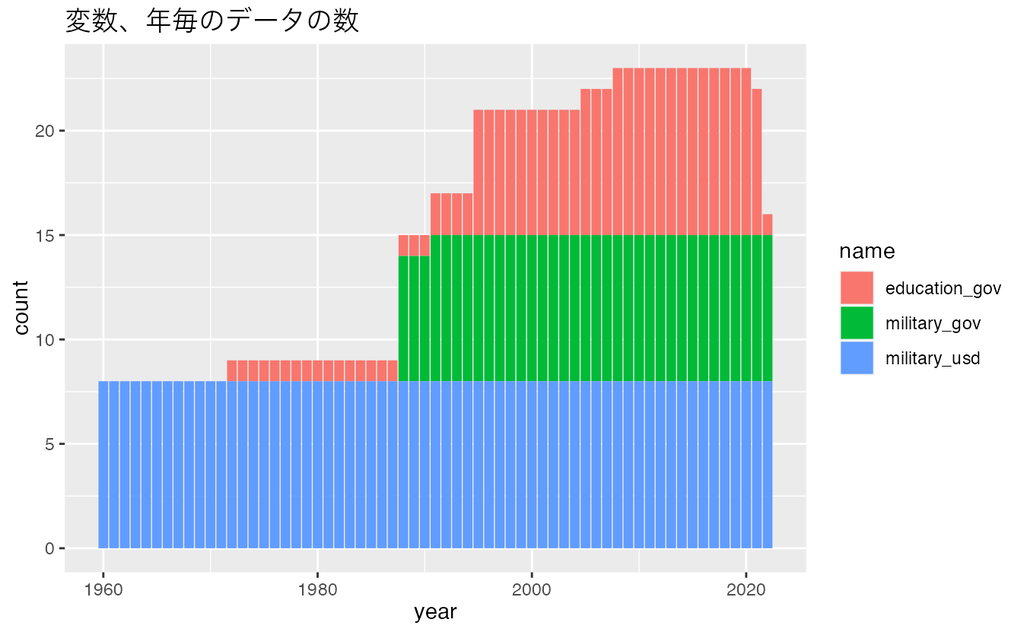

```r
df_military_ed_long |> drop_na(value) |>
  ggplot(aes(year, fill = name)) + geom_bar() + labs(title = "変数、年毎のデータの数")
```

**気づいたこと・疑問**

- データの指標ごとに、数が異なる。軍事費（USD）は、1960年から、すべてについてあるようだが、他はそれほど一定していない
- 最近では、2020年は、すべての変数において、データが多いと思われる。

### 2. 経年変化を表す折れ線グラフ

#### 日本の軍事費と、教育費を、G7 の中で見る。

７カ国＋EU なので、まずは、別々の指標ごとに、経年変化を調べる。

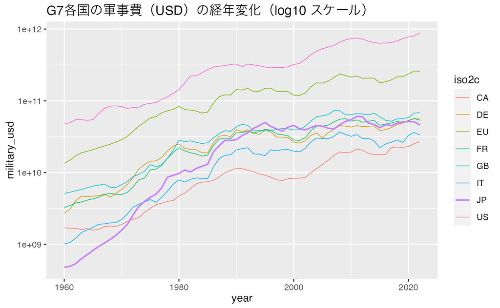

```r
df_military_ed |> drop_na(military_usd) |>
  ggplot(aes(year, military_usd, col = iso2c, linewidth = iso2c)) + geom_line() +
  scale_y_log10() + scale_linewidth_manual(values = c(0.3,0.3,0.3,0.3,0.3,0.3,0.7,0.3)) +
  labs(title = "G7各国の軍事費（USD）の経年変化（log10 スケール）")
```

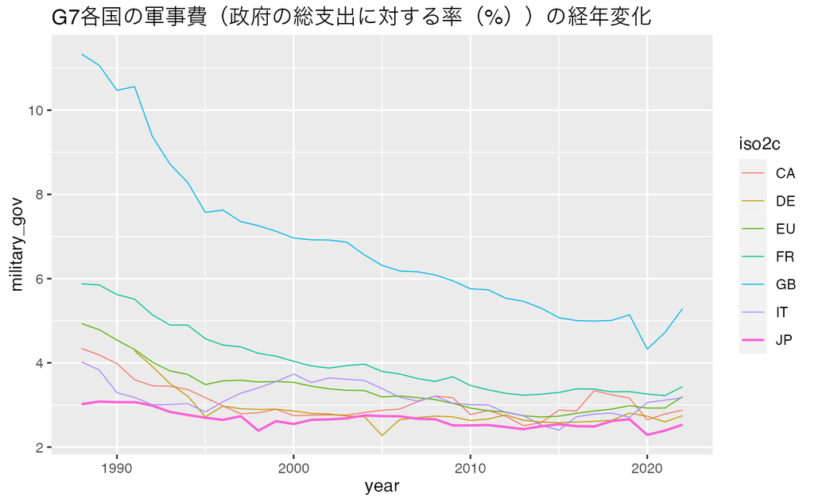

```r
df_military_ed |> drop_na(military_gov) |>
  ggplot(aes(year, military_gov, col = iso2c, linewidth = iso2c)) + geom_line() + scale_linewidth_manual(values = c(0.3,0.3,0.3,0.3,0.3,0.3,0.7,0.3)) +
  labs(title = "G7各国の軍事費（政府の総支出に対する率（%））の経年変化")
```

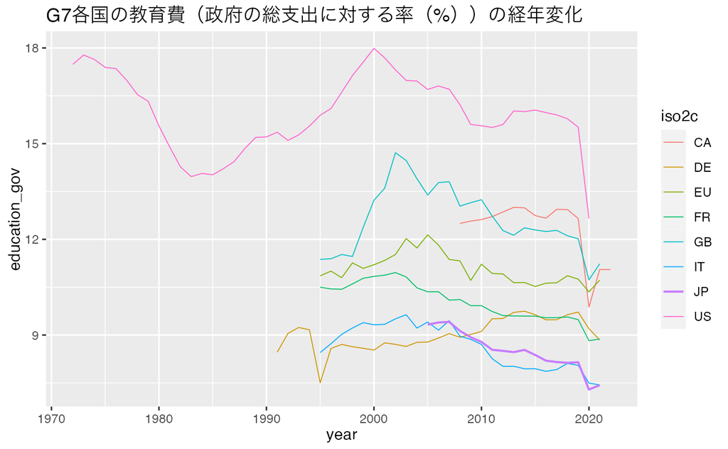

```r
df_military_ed |> drop_na(education_gov) |>
  ggplot(aes(year, education_gov, col = iso2c, linewidth = iso2c)) + geom_line() + scale_linewidth_manual(values = c(0.3,0.3,0.3,0.3,0.3,0.3,0.7,0.3)) +
  labs(title = "G7各国の教育費（政府の総支出に対する率（%））の経年変化")
```

**気づいたこと・疑問・備考**

- 軍事費は、政府総支出に対する割合（％）でみると高くないが、総支出額でみると、アメリカを除くと、少ないとは言えない。
- 教育費の政府総支出に対する割合（％）は減少しており、最低レベルと思われる。
- 軍事費の総支出額は、アメリカが突出しているため、他の国について見分けるのが難しいので、log10 スケールを用いた。

### 日本と、日本以外のG7 の軍事費と教育費の（政府の総支出に対する率（%））

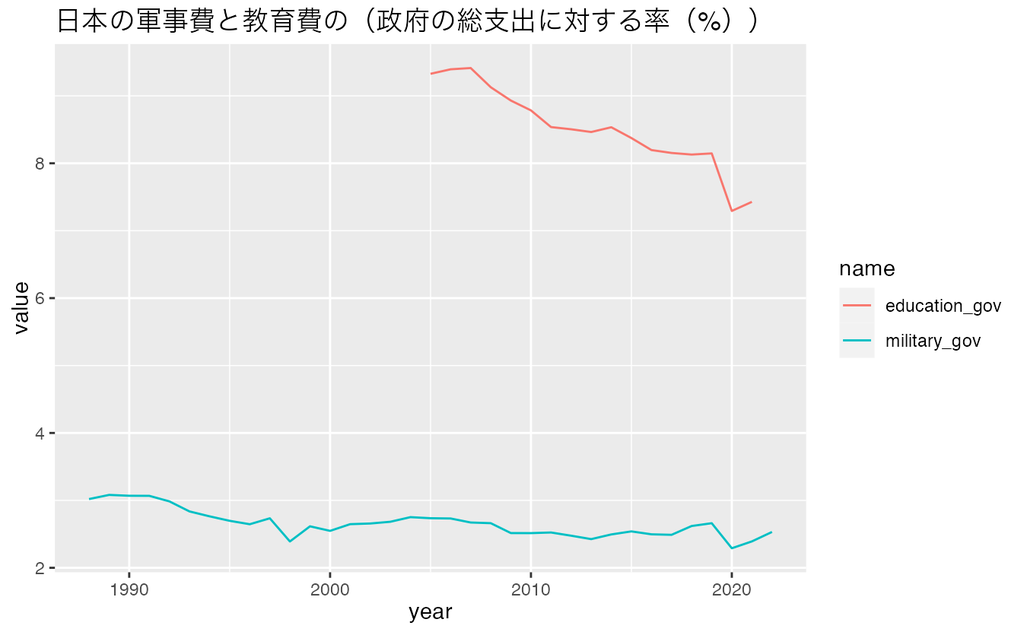

```r
df_military_ed_long |> filter(name != "military_usd", iso2c == "JP") |> drop_na(value) |>
  ggplot(aes(year, value, col = name)) + geom_line() +
  labs(title = "日本の軍事費と教育費の（政府の総支出に対する率（%））")
```

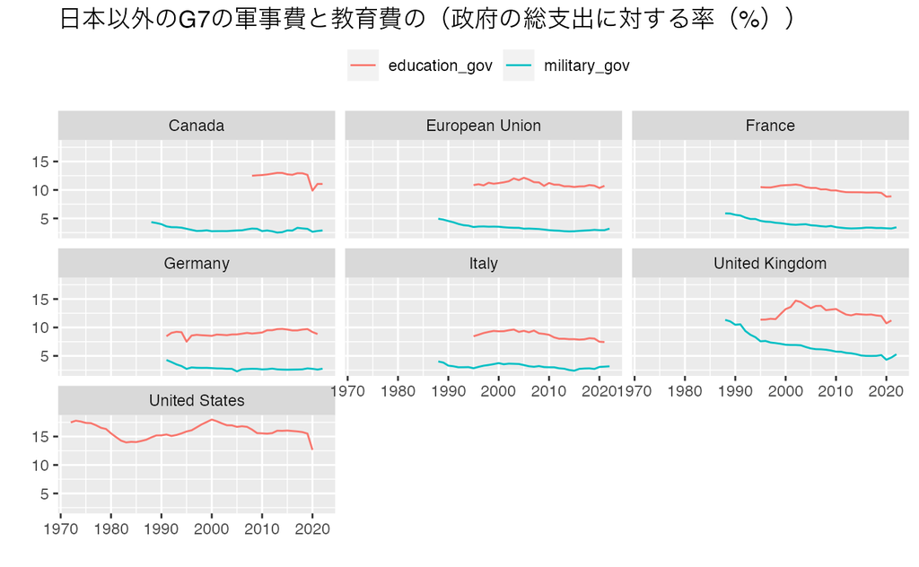

```r
df_military_ed_long |> filter(name != "military_usd", iso2c != "JP") |> drop_na(value) |>
  ggplot(aes(year, value, col = name)) + geom_line() + facet_wrap(~country) +
  labs(title = "日本以外のG7の軍事費と教育費の（政府の総支出に対する率（%））",
       x = "", y = "", col = "") +
  theme(legend.position = "top")
```

**気づいたこと・疑問・備考**

### 4. 2020年の国別比較の棒グラフ

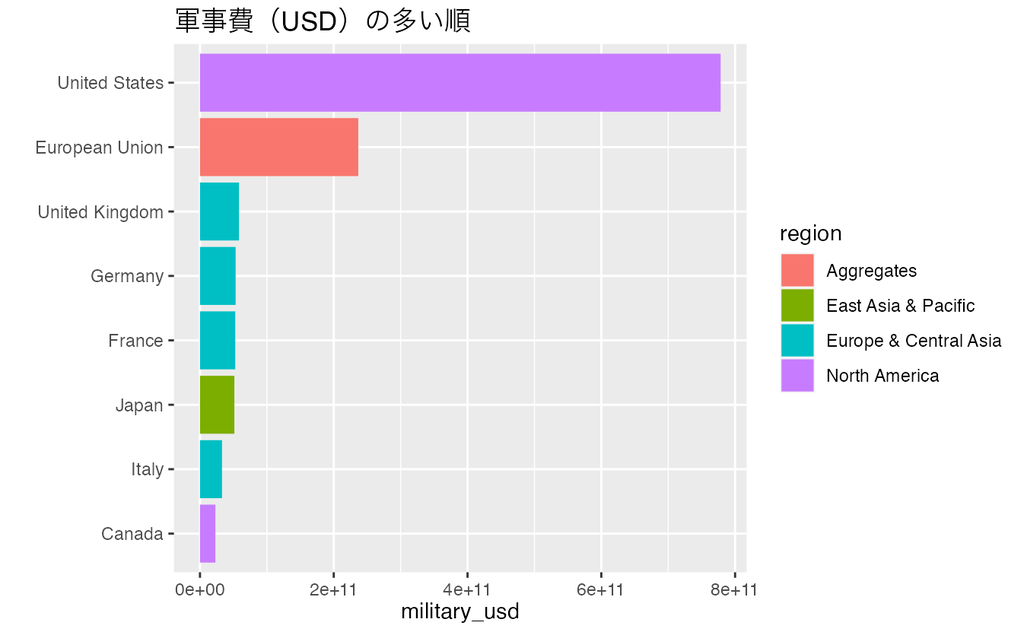

```r
df_military_ed |> filter(year == 2020) |> drop_na(military_usd) |> arrange(desc(military_usd)) |>
  ggplot(aes(fct_rev(fct_inorder(country)), military_usd, fill = region)) + geom_col() +
  coord_flip() + labs(title = "軍事費（USD）の多い順", x = "")
```

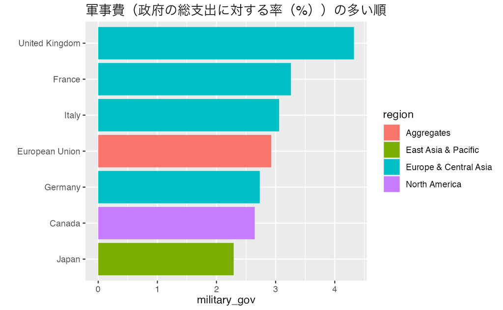

```r
df_military_ed |> filter(year == 2020) |> drop_na(military_gov) |> arrange(desc(military_gov)) |>
  ggplot(aes(fct_rev(fct_inorder(country)), military_gov, fill = region)) + geom_col() +
  coord_flip() + labs(title = "軍事費（政府の総支出に対する率（%））の多い順", x = "")
```

**気づいたこと・疑問・備考**

- 日本の軍事費のGDP費は、1.3%ぐらいだったと記憶しているので（要確認）それを、2% にあげるということは、1.5倍強ということになる。政府予算は、それほど上昇しないとすると、日本は、英国の次になる。額では、アメリカに次ぐレベルになることと思われる。周囲の国が心配するのは、当然に思う。

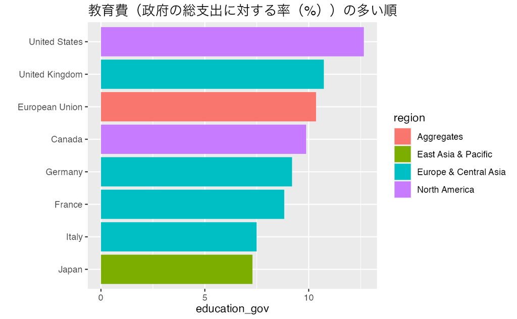

```r
df_military_ed |> filter(year == 2020) |> drop_na(education_gov) |> arrange(desc(education_gov)) |>
  ggplot(aes(fct_rev(fct_inorder(country)), education_gov, fill = region)) + geom_col() +
  coord_flip() + labs(title = "教育費（政府の総支出に対する率（%））の多い順", x = "")
```

**気づいたこと・疑問・備考**

- 経年変化のグラフで確認したように、日本は、最低レベルである。教育に投資しないで、将来的に大丈夫なのだろうか。

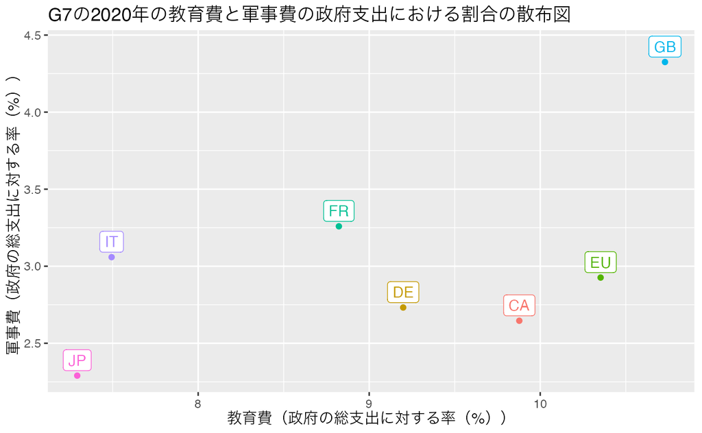

```r
df_military_ed |> filter(year == 2020) |> drop_na(military_gov, education_gov) |>
  ggplot(aes(education_gov, military_gov, col = iso2c)) + geom_point() + geom_label(aes(label = iso2c), nudge_y = 0.1) + theme(legend.position = "none") +
  labs(title = "G7の2020年の教育費と軍事費の政府支出における割合の散布図", x = "教育費（政府の総支出に対する率（%））", y = "軍事費（政府の総支出に対する率（%））")
```

**気づいたこと・疑問**

- 政府予算の傾向をみて取ることができる。日本は、社会保障費が高いのかもしれない。